# Shaming project - reliability

For measuring intercoder reliability, check this [link](http://www.cookbook-r.com/Statistical_analysis/Inter-rater_reliability/)

### Initialize script

```r
knitr::opts_chunk$set(echo = FALSE, message=FALSE, warning=FALSE)
library(tidyverse)
library(glue)
library(irr, quietly = T)
data_folder <- file.path("..", "data")
output_folder <- file.path("..", "output")
```

### Load data

Most data for calculating intercoder reliability are stored in a dedicated folder except for the Neural Monkey results, which have their own folder. This chunk simply loads relevants files. When new intercoder data arrive, they should be sourced here.

# Prepare data for testing

| sentiment | n | total | sample_pct | pop_pct |
| --- | --- | --- | --- | --- |
| negative | 91 | 150 | 0.6066667 | 0.5921601 |
| neutral | 29 | 150 | 0.1933333 | 0.1887818 |
| positive | 30 | 150 | 0.2000000 | 0.2190581 |

## Reliability with Neural Monkey

This chunk calculates the scores for humans with the Neural Monkey classifier.

```
 Krippendorff's alpha

 Subjects = 150
   Raters = 2
    alpha = 0.634

Kappa for human agreement 0.64172813487882,
Kappa for R-computer agreement 0.0828424427708597,
Kappa for M-computer agreement 0.0829427348685551,
Fleiss Kappa for all 3 coders 0.254439583065243
```

## Reliability with lexicon - test no. 1

This chunk calculates the pairwise scores for humans and for a rule-based lexicon method for sentiment detection. 150 items were coded by two human coders. The baseline lexicon sentiment is defined as:

- POS = NEG = 0 ~ “neutral”
- POS = NEG ~ “neutral”,
- POS > NEG ~ “positive”,
- NEG > POS ~ “negative”

```
 Krippendorff's alpha

 Subjects = 150
   Raters = 2
    alpha = 0.634

Kappa for human agreement 0.64172813487882,
Kappa for R-computer agreement 0.394039735099338,
Kappa for M-computer agreement 0.244357212953876,
Fleiss Kappa for all 3 coders 0.410573130054678
```

## Coders’ disagreements in round 1 of testing

Prepare data by finding agreements and disagreements.

Once disagreements are resolved, keep the golden data for

- training
- to filter out from the main data set in future sampling procedures

# Use data from the first test of reliability to train a classifier

Class proportions in gold data:

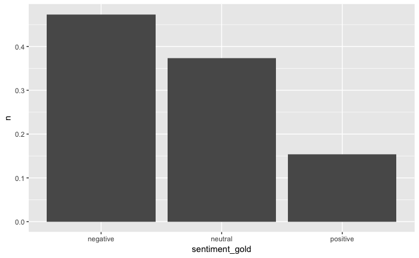

### Features:

- counts of positive/negative/neutral
- + count of negative prepositions

### Results from cross-validation (80% train):__

```
L2 Regularized Support Vector Machine (dual) with Linear Kernel

121 samples
  4 predictor
  3 classes: 'negative', 'neutral', 'positive'

No pre-processing
Resampling: Cross-Validated (10 fold, repeated 3 times)
Summary of sample sizes: 111, 108, 109, 108, 109, 108, ...
Resampling results across tuning parameters:

  cost  Loss  Accuracy   Kappa
  0.25  L1    0.6158819  0.3812009
  0.25  L2    0.6330925  0.4017688
  0.50  L1    0.6061305  0.3654266
  0.50  L2    0.6381818  0.4126716
  1.00  L1    0.6233605  0.3923893
  1.00  L2    0.6381818  0.4137052

Accuracy was used to select the optimal model using the largest value.
The final values used for the model were cost = 0.5 and Loss = L2.
Cross-Validated (10 fold, repeated 3 times) Confusion Matrix

(entries are percentual average cell counts across resamples)

          Reference
Prediction negative neutral positive
  negative     28.9     9.1      0.6
  neutral      15.4    26.4      6.6
  positive      2.8     1.7      8.5

 Accuracy (average) : 0.6391
```

### Prediction on the held out set (20% test):

```
Confusion Matrix and Statistics


predictions_model_1 negative neutral positive
           negative        9       0        2
           neutral         5       9        0
           positive        0       2        2

Overall Statistics

               Accuracy : 0.6897
                 95% CI : (0.4917, 0.8472)
    No Information Rate : 0.4828
    P-Value [Acc > NIR] : 0.01989

                  Kappa : 0.4952
 Mcnemar's Test P-Value : 0.02929

Statistics by Class:

                     Class: negative Class: neutral Class: positive
Sensitivity                   0.6429         0.8182         0.50000
Specificity                   0.8667         0.7222         0.92000
Pos Pred Value                0.8182         0.6429         0.50000
Neg Pred Value                0.7222         0.8667         0.92000
Prevalence                    0.4828         0.3793         0.13793
Detection Rate                0.3103         0.3103         0.06897
Detection Prevalence          0.3793         0.4828         0.13793
Balanced Accuracy             0.7548         0.7702         0.71000
```

### Crossvalidated model 2 (use all data, no held out test set)

[output not shown]

### Accuracy of the model 2 on the train data

```
Confusion Matrix and Statistics


predictions_model_2 negative neutral positive
           negative       50      11        3
           neutral        19      43       12
           positive        2       2        8

Overall Statistics

               Accuracy : 0.6733
                 95% CI : (0.5921, 0.7476)
    No Information Rate : 0.4733
    P-Value [Acc > NIR] : 6.084e-07

                  Kappa : 0.457
 Mcnemar's Test P-Value : 0.02359

Statistics by Class:

                     Class: negative Class: neutral Class: positive
Sensitivity                   0.7042         0.7679         0.34783
Specificity                   0.8228         0.6702         0.96850
Pos Pred Value                0.7812         0.5811         0.66667
Neg Pred Value                0.7558         0.8289         0.89130
Prevalence                    0.4733         0.3733         0.15333
Detection Rate                0.3333         0.2867         0.05333
Detection Prevalence          0.4267         0.4933         0.08000
Balanced Accuracy             0.7635         0.7190         0.65817
```

Prepare a second sample for manual coding

Evaluate the second round of manual coding.

```
NAs introduced by coercion
```

```
 Krippendorff's alpha

 Subjects = 150
   Raters = 2
    alpha = 0.846
 Cohen's Kappa for 2 Raters (Weights: unweighted)

 Subjects = 150
   Raters = 2
    Kappa = 0.846

        z = 13.6
  p-value = 0
 Cohen's Kappa for 2 Raters (Weights: unweighted)

 Subjects = 150
   Raters = 2
    Kappa = 0.275

        z = 4.97
  p-value = 6.7e-07
 Cohen's Kappa for 2 Raters (Weights: unweighted)

 Subjects = 150
   Raters = 2
    Kappa = 0.32

        z = 5.82
  p-value = 6.03e-09
 Fleiss' Kappa for m Raters

 Subjects = 150
   Raters = 3
    Kappa = 0.463

        z = 13.4
  p-value = 0
```

# Use data from the *second* test of reliability to train an improved classifier

| id | message | sentiment_marketa | sentiment_radim |
| --- | --- | --- | --- |
| 619253204811080_1825329 | Bude prosím díl i v TV? | neutral | neutral |
| 821497657919966_821539647915767 | Fakt už to přeháněj no. Evidentně, jim to dělá asi dobře no | negative | negative |
| 819759788093753_819964271406638 | Já si myslím že to soc. neunikne... | neutral | neutral |
| 821497657919966_821526314583767 | To neni po trech letech | neutral | neutral |
| 1116549235081472_1116614275074968 | Dva výučné listy? :D Obor: Jsem kráva a krávou budu. :D Bravo! Zatleskej si. :D Modrá laguna je krásná. Děkuji za kompliment. :D | negative | negative |
| 829918620411203_829932133743185 | Děda je super chlap | positive | positive |
| 155435151192890_878756955527369 | Ano pozná, velmi rychle a nepříjemně! Tohle vás čeká už dnes v novém díle Výměny manželek! Přečtěte si i pecky z manuálů: http://bit.ly/1MDPVjU | negative | negative |
| 811369605599438_811669338902798 | Divím se ze sociální úřad s tím nic nedělá.... | neutral | neutral |
| 862890163780715_862939833775748 | dakujem pekne | positive | positive |
| 795085590561173_795356930534039 | Co vy ste zac, asi pan dokonalej, radeji se nevyjadrujte je videt jak vy se sve rodiny nezastanete at to stoji co to stoji | negative | negative |

[output cut: 126 more lines]